# Population Genomics Project

Angelos Galanopoulos

2023-06-30

# 1 Introduction

In this assignment, we explore the SNPs of chromosome 6 (chrVI) of the three-spined stickleback (*Gasterosteus aculeatus* Linnaeus, 1758) and other metadata (body length,weight) in relation to the habitat (either brackish water or freshwater) of 8 different populations.

The dataset is part of the Raeymaekers et al. (2017). The VCF file contains **192 samples** from three-spined stickleback populations. There are **eight populations** from **brackish and freshwater** habitats. Populations L01, L02, L03, L05 come from brackish water while populations L07, L09, L10, L12 come from freshwater.From each site approximately 24 individuals have been sequenced using WGS. Samples have been taken from the Belgian-Dutch lowlands.

In this VCF file we have removed monomorphic SNPs to exclude all sites at which no alternative alleles are called for any of the samples and all sites at which only alternative alleles are called (all samples differ from the reference genome). Furthermore, multiallelic and low allele frequency (AF < 0.01) SNPs have also been removed.

The questions that I address in this assignment are:

- **Is there a significant difference in the body weight between the two habitats?**
- **Is there a significant difference in the body length between the two habitats?**
- **Are the genetic differences between habitats (based of the Fst values) significant?**
- **What is the percent heterozygocity in each population/habitat?**
- **Do the different populations cluster together based on their respective habitat?**

# 2 Methods and Results

## 2.1 Getting started

The VCF file contains SNPs from all across the three-spined stickleback’s genome. In order to start the analysis, we first subset the VCF to keep only the SNPs located on the sixth chromosome (chrVI) using the following linux command:

```bash
zcat ThreeSpined_biallelicAFmonFMFPASS_SNP.vcf.gz | awk '/^##|^#CHROM|^chrVI\t/' > ChromosomeVI.vcf
```

We can confirm that we only selected the VI chromosome’s variants (and not for example variants from chromosomes VII or VIII) using the command:

```bash
bcftools query -f '%CHROM\n' ChromosomeVI.vcf | uniq
```

whose output should be “chrVI”.

Then we move to R to set the working directory:

```r
knitr::opts_knit$set(root.dir = 'C:/Users/angel/Desktop/Applied Bioinformatics/2nd Semester/Population Genomics/PopulationGenomics_Assignment/')
```

import the required libraries:

```r
library("data.table")
library("vcfR")
library("devtools")
library("DEMEtics")
library("StAMPP")
library("gridExtra")
library("readr")
library("ggplot2")
library("adegenet")
library("ape")
```

and finally import the subsetted data:

```r
# Specify the path to the subsetted VCF file
vcf_file <- "C:/Users/angel/Desktop/Applied Bioinformatics/2nd Semester/Population Genomics/PopulationGenomics_Assignment/data/ChromosomeVI.vcf"

# Read the VCF file
vcf <- read.vcfR(vcf_file)

#load the info files
SampleInfo <- read.table(file = "data/SamplesInfo.txt", sep = "\t", header=TRUE)
SitesInfo <- read.table(file = "data/SitesInfo.txt", sep = "\t", header=TRUE)
```

## 2.2 Exploring the data

We can now inspect the data and the info files.

```r
head(vcf)
```

```
## [1] "***** Object of class 'vcfR' *****"
## [1] "***** Meta section *****"
## [1] "##fileformat=VCFv4.2"
## [1] "##FILTER=<ID=PASS,Description=\"All filters passed\">"
## [1] "##ALT=<ID=NON_REF,Description=\"Represents any possible alternative a [Truncated]"
## [1] "##FILTER=<ID=FAIL_FS60,Description=\"FS > 60.0\">"
## [1] "##FILTER=<ID=FAIL_MQ50,Description=\"MQ < 50.0\">"
## [1] "##FILTER=<ID=FAIL_QD5,Description=\"QD < 5.0\">"
## [1] "First 6 rows."
## [1]
## [1] "***** Fixed section *****"
##      CHROM   POS    ID REF ALT QUAL      FILTER
## [1,] "chrVI" "4992" NA "C" "T" "474.88"  "PASS"
## [2,] "chrVI" "6075" NA "A" "T" "57227.9" "PASS"
## [3,] "chrVI" "6574" NA "G" "A" "11026"   "PASS"
```

[output cut: 45 more lines]

```r
head(SampleInfo)
```

```
##           SeqID        ID Species Site Dissected Sex Length.cm. Body_weight.g.
## 1 Sample_01-131 TMS_00014      3S  L12         1   M        4.9           1.96
## 2   Sample_01-2 TMS_00021      3S  L12         1   F        5.2           2.22
## 3 Sample_02-253 TMS_00338      3S  L03         1   F        5.8           4.40
## 4 Sample_02-350 TMS_00439      3S  L07         1   M        4.4           0.95
## 5   Sample_02-3 TMS_00056      3S  L12         3   F        5.4           2.14
## 6 Sample_03-133 TMS_00293      3S  L01         1   M        4.2           0.99
```

```r
head(SitesInfo)
```

```
##   Site Latitude Longitude       Habitat
## 1  L01 51.35791  3.444077 Brackishwater
## 2  L02 51.37349  3.524563 Brackishwater
## 3  L03 51.28850  3.594585 Brackishwater
## 4  L05 51.24066  3.303227 Brackishwater
## 5  L07 51.23914  3.654950    Freshwater
## 6  L09 51.19932  3.666218    Freshwater
```

```r
str(vcf) # this shows the structure of the file/object and can display the contents of it
```

```
## Formal class 'vcfR' [package "vcfR"] with 3 slots
##   ..@ meta: chr [1:73] "##fileformat=VCFv4.2" "##FILTER=<ID=PASS,Description=\"All filters passed\">" "##ALT=<ID=NON_REF,Description=\"Represents any possible alternative allele not already represented at this loca"| __truncated__ "##FILTER=<ID=FAIL_FS60,Description=\"FS > 60.0\">" ...
##   ..@ fix : chr [1:158868, 1:8] "chrVI" "chrVI" "chrVI" "chrVI" ...
##   .. ..- attr(*, "dimnames")=List of 2
##   .. .. ..$ : NULL
##   .. .. ..$ : chr [1:8] "CHROM" "POS" "ID" "REF" ...
##   ..@ gt  : chr [1:158868, 1:193] "GT:AD:DP:GQ:PL" "GT:AD:DP:GQ:PGT:PID:PL:PS" "GT:AD:DP:GQ:PGT:PID:PL:PS" "GT:AD:DP:GQ:PGT:PID:PL:PS" ...
##   .. ..- attr(*, "dimnames")=List of 2
##   .. .. ..$ : NULL
##   .. .. ..$ : chr [1:193] "FORMAT" "Sample_01-131" "Sample_01-2" "Sample_02-253" ...
```

```r
vcf@fix[1:10,1:5] # this shows the alleles for the first 10 SNPs
```

```
##       CHROM   POS    ID REF ALT
##  [1,] "chrVI" "4992" NA "C" "T"
##  [2,] "chrVI" "6075" NA "A" "T"
##  [3,] "chrVI" "6574" NA "G" "A"
##  [4,] "chrVI" "6673" NA "T" "C"
##  [5,] "chrVI" "6677" NA "T" "C"
##  [6,] "chrVI" "6681" NA "G" "C"
##  [7,] "chrVI" "6690" NA "T" "C"
##  [8,] "chrVI" "8438" NA "G" "C"
##  [9,] "chrVI" "8600" NA "A" "G"
## [10,] "chrVI" "8777" NA "T" "C"
```

We start the analysis by creating a few plots so that we can get an idea about our data.

### 2.2.1 Visual overview of the SNP data

In order to explore the data, we need the reference genome. I downloaded the stickleback whole genome assembly v5 from this website (https://stickleback.genetics.uga.edu/downloadData/).

We can now explore the VCF file in a visual way with the following commands:

```r
dna_file <- read.dna("data/stickleback_v5_assembly.fa",format="fasta")
# This reads in the underlying genome file

chrom <- create.chromR(name="chrVI", vcf=vcf, seq=dna_file, verbose=TRUE)
# This function combines the sequence and variation information

chrom <- proc.chromR(chrom, verbose = TRUE,win.size=10)
# This function calls several helper functions to process the variant,
# sequence and  annotation data for visualization. Choosing win.size=10
# summarizes the data over 10bp windows
```

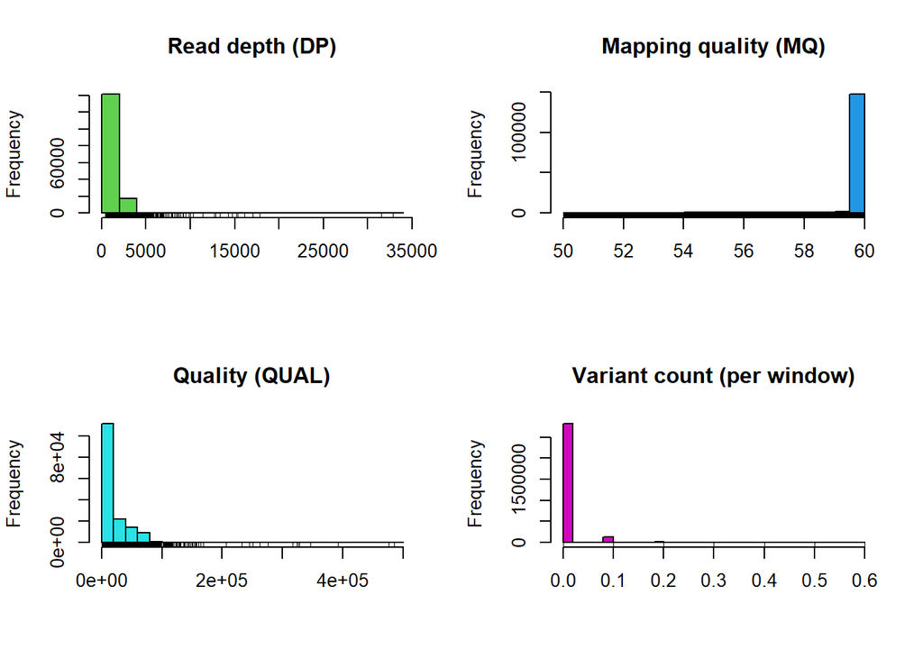

```r
plot(chrom)
```

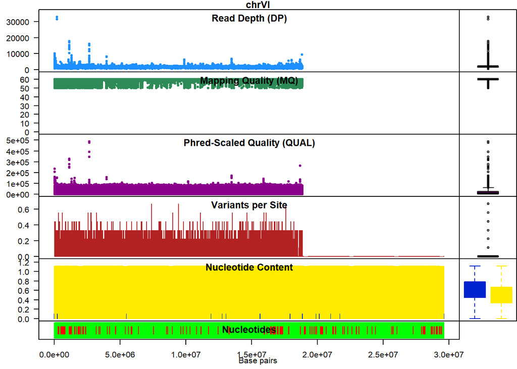

```r
chromoqc(chrom)
```

### 2.2.2 Allele depths

To extract the allele depths for each sample (DP field of VCF) and plot its distribution, we use the following command:

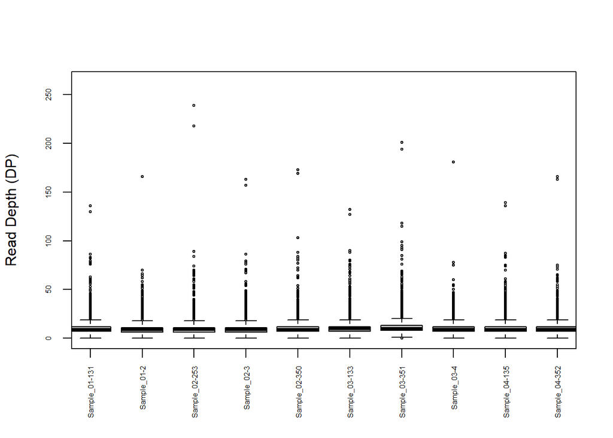

```r
dp <- extract.gt(vcf, element='DP', as.numeric=TRUE)

boxplot(dp, las=3, col=c("#C0C0C0", "#808080"), ylab="Read Depth (DP)", cex=0.4, cex.axis=0.5,xlim=c(1,10))
```

### 2.2.3 genlight objects

Continuing the analysis, we convert the vcf data to a genlight object for ease of use:

```r
genlight.data <- vcfR2genlight(vcf)
```

We can now check some info in the genlight object

```r
indNames(genlight.data) #individual names
```

```
##   [1] "Sample_01-131" "Sample_01-2"   "Sample_02-253" "Sample_02-3"
##   [5] "Sample_02-350" "Sample_03-133" "Sample_03-351" "Sample_03-4"
##   [9] "Sample_04-135" "Sample_04-352" "Sample_04-5"   "Sample_05-138"
##  [13] "Sample_05-353" "Sample_06-139" "Sample_06-257" "Sample_07-141"
##  [17] "Sample_07-258" "Sample_07-355" "Sample_08-259" "Sample_09-357"
##  [21] "Sample_10-152" "Sample_10-358" "Sample_12-158" "Sample_12-263"
##  [25] "Sample_13-264" "Sample_13-361" "Sample_14-23"  "Sample_14-265"
##  [29] "Sample_14-362" "Sample_15-363" "Sample_16-164" "Sample_16-25"
##  [33] "Sample_16-267" "Sample_16-364" "Sample_17-1"   "Sample_17-365"
##  [37] "Sample_18-12"  "Sample_18-269" "Sample_18-366" "Sample_19-13"
##  [41] "Sample_20-15"  "Sample_20-172" "Sample_20-271" "Sample_21-29"
##  [45] "Sample_22-31"  "Sample_23-176" "Sample_23-274" "Sample_24-275"
##  [49] "Sample_26-179" "Sample_26-277" "Sample_26-35"  "Sample_27-180"
##  [53] "Sample_27-36"  "Sample_27-375" "Sample_28-376" "Sample_29-182"
##  [57] "Sample_29-280" "Sample_29-38"  "Sample_30-183" "Sample_30-39"
```

[output cut: 33 more lines]

```r
nLoc(genlight.data) # number of SNPs
```

```
## [1] 158868
```

We can add information about the ploidy of this species.

```r
ploidyvalues <- rep(2,192)
ploidy(genlight.data) <- ploidyvalues
```

We can add information about the site each sample comes from.

```r
pops <- as.factor(c(SampleInfo$Site))
pop(genlight.data) <- pops
```

```r
as.matrix(genlight.data)[20:30,1:5]
```

```
##               chrVI_4992 chrVI_6075 chrVI_6574 chrVI_6673 chrVI_6677
## Sample_09-357          0          2          0          0          0
## Sample_10-152          0          2          1         NA         NA
## Sample_10-358          0          2          1          1          1
## Sample_12-158          0         NA          1         NA         NA
## Sample_12-263          0          2          0          0          0
## Sample_13-264          0          2          1         NA         NA
## Sample_13-361          1          2          0          1          1
## Sample_14-23           0          1          0          0          0
## Sample_14-265          0          2          1         NA         NA
## Sample_14-362          0          2          1          0          0
## Sample_15-363          1          2          0          0          0
```

A graphical overview of alternative alleles and missing data (in white) can be obtained with the glPlot function:

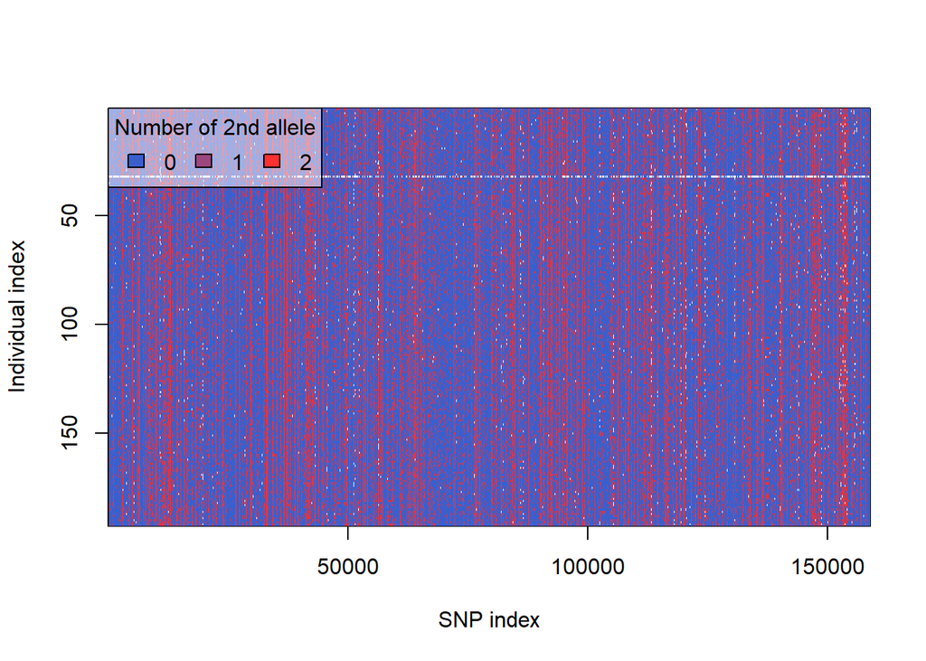

```r
glPlot(genlight.data, posi="topleft")
```

To assess the position of the polymorphic sites within a chromosome graphically, we can use:

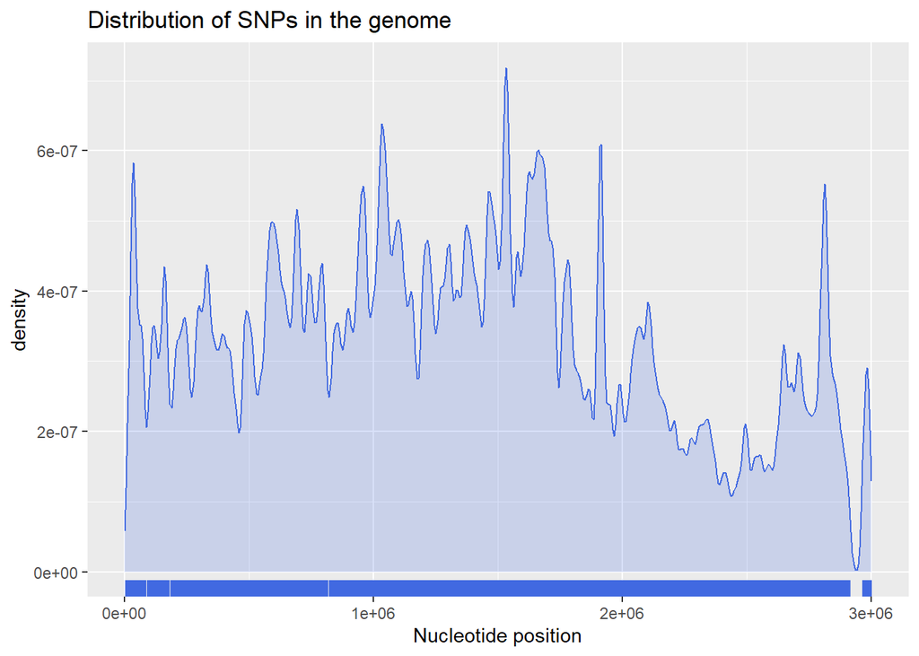

```r
snpposi.plot(position(genlight.data[,genlight.data$chromosome=="chrVI"]),genome.size=3000000,codon=FALSE)
```

### 2.2.4 Allele frequency spectrum

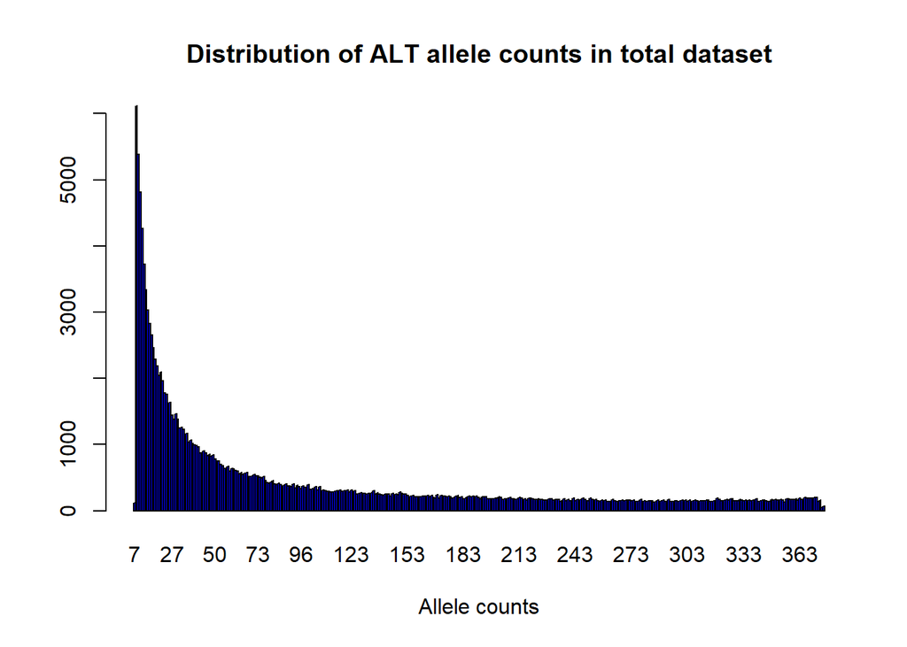

```r
#plot total AFS of the dataset
mySum <- glSum(genlight.data, alleleAsUnit = TRUE) # Computes the sum of second alleles for each SNP.
barplot(table(mySum), col="blue", space=0, xlab="Allele counts",
main="Distribution of ALT allele counts in total dataset")
```

## 2.3 Body length ~ habitat correlation

In order to infer if there is a significant difference in body length between the two habitats, we first calculate the **mean and median (not affected by outliers) body length** for each habitat:

```r
#calculate the mean body length for each habitat
#brackish
mean(SampleInfo$Length.cm.[SampleInfo$Site %in% c("L01", "L02", "L03", "L05")])
```

```
## [1] 4.398958
```

```r
#fresh
mean(SampleInfo$Length.cm.[SampleInfo$Site %in% c("L07", "L09", "L10", "L012")])
```

```
## [1] 4.501389
```

```r
#calculate the median body length for each habitat
#brackish
median(SampleInfo$Length.cm.[SampleInfo$Site %in% c("L01", "L02", "L03", "L05")])
```

```
## [1] 4.4
```

```r
#fresh
median(SampleInfo$Length.cm.[SampleInfo$Site %in% c("L07", "L09", "L10", "L012")])
```

```
## [1] 4.35
```

We can see that there is a very small difference in mean and median body length between the two habitats.

Then, we create a comparative boxplot:

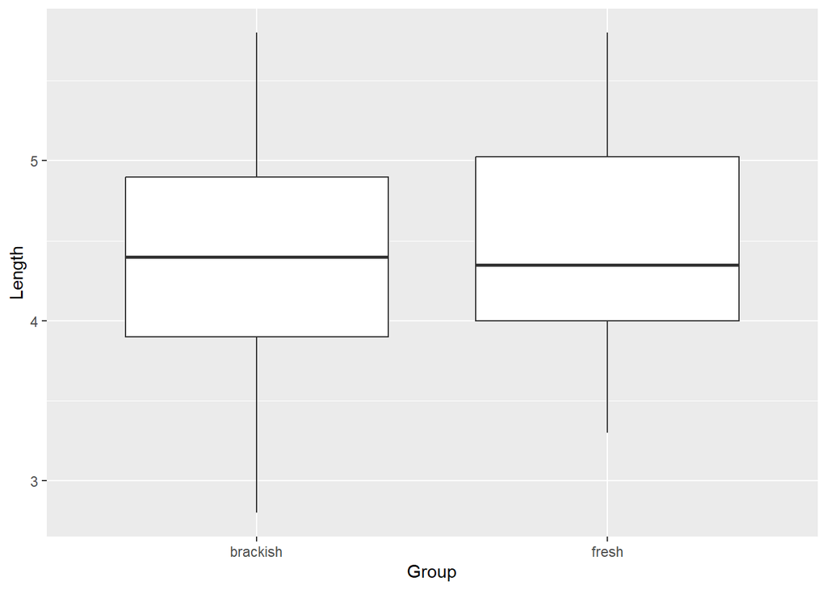

```r
#Length boxplots for each habitat
groups <- c("brackish","fresh")
brackishL <- c(SampleInfo$Length.cm.[SampleInfo$Site %in% c("L01", "L02", "L03", "L05")])
freshL <- c(SampleInfo$Length.cm.[SampleInfo$Site %in% c("L07", "L09", "L10", "L012")])
data <- data.frame(
  Group = factor(c(rep("brackish", length(brackishL)), rep("fresh", length(freshL)))),
  Value = c(brackishL, freshL)
)
ggplot(data, aes(x = Group, y = Value)) +
  geom_boxplot() +
  ylab("Length") +
  xlab("Group")
```

Finally, we perform a Wilcoxon test to see if this difference in length is significant:

```r
resultL <- wilcox.test(brackishL, freshL)
print(resultL)
```

```
##
##  Wilcoxon rank sum test with continuity correction
##
## data:  brackishL and freshL
## W = 3270.5, p-value = 0.5526
## alternative hypothesis: true location shift is not equal to 0
```

We can see that the difference in length is not significant according to this test.

## 2.4 Body weight ~ habitat correlation

We do the same as above for the body weight.

```r
#calculate the mean body weight for each habitat
#brackish
mean(SampleInfo$Body_weight.g.[SampleInfo$Site %in% c("L01", "L02", "L03", "L05")], na.rm = TRUE)
```

```
## [1] 1.427789
```

```r
#fresh
mean(SampleInfo$Body_weight.g.[SampleInfo$Site %in% c("L07", "L09", "L10", "L012")], na.rm = TRUE)
```

```
## [1] 1.325417
```

```r
#calculate the median body weight for each habitat
#brackish
median(SampleInfo$Body_weight.g.[SampleInfo$Site %in% c("L01", "L02", "L03", "L05")],na.rm = TRUE)
```

```
## [1] 1.31
```

```r
#fresh
median(SampleInfo$Body_weight.g.[SampleInfo$Site %in% c("L07", "L09", "L10", "L012")])
```

```
## [1] 1.085
```

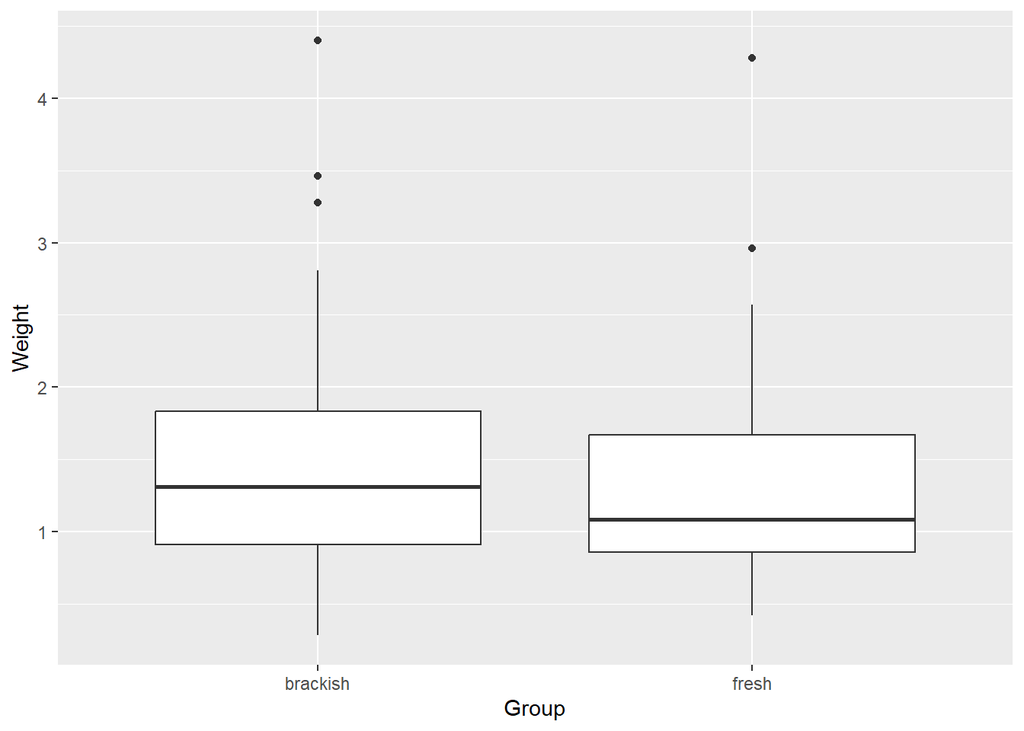

```r
#Weight boxplots for each habitat
groups <- c("brackish","fresh")
brackishW <- c(SampleInfo$Body_weight.g.[SampleInfo$Site %in% c("L01", "L02", "L03", "L05")])
freshW <- c(SampleInfo$Body_weight.g.[SampleInfo$Site %in% c("L07", "L09", "L10", "L012")])
data <- data.frame(
  Group = factor(c(rep("brackish", length(brackishW)), rep("fresh", length(freshW)))),
  Value = c(brackishW, freshW)
)
ggplot(data, aes(x = Group, y = Value)) +
  geom_boxplot() +
  ylab("Weight") +
  xlab("Group")
```

Finally, we perform a Wilcoxon test to see if this difference in weight is significant:

```r
resultW <- wilcox.test(brackishW, freshW)
print(resultW)
```

```
##
##  Wilcoxon rank sum test with continuity correction
##
## data:  brackishW and freshW
## W = 3750, p-value = 0.2869
## alternative hypothesis: true location shift is not equal to 0
```

We can see that the difference in weight is not significant according to this test.

## 2.5 Genetic differentiantion

Calculating genetic differentiation with the full set of SNPs takes too much time. Thus, we randomly select 50000 of these 158868 SNPs.

```r
genlight.data.reduced <- genlight.data[,sample(1:158868, 50000)]
genlight.data.reduced #checking basic information
```

```
##  /// GENLIGHT OBJECT /////////
##
##  // 192 genotypes,  50,000 binary SNPs, size: 6.7 Mb
##  81296 (0.85 %) missing data
##
##  // Basic content
##    @gen: list of 192 SNPbin
##    @ploidy: ploidy of each individual  (range: 2-2)
##
##  // Optional content
##    @ind.names:  192 individual labels
##    @loc.names:  50000 locus labels
##    @chromosome: factor storing chromosomes of the SNPs
##    @position: integer storing positions of the SNPs
##    @pop: population of each individual (group size range: 24-24)
##    @other: a list containing: elements without names
```

The metric that we calculate to measure genetic differentiation between the populations are the Fst values. We calculate the Fst values from this reduced set of SNPs with the ‘StAMPP’ package:

```r
FstValues <- stamppFst(genlight.data.reduced, nboots = 100, percent = 95)
```

```r
FstValues$Fsts
```

```
##            L12         L03        L07         L01        L02        L09
## L12         NA          NA         NA          NA         NA         NA
## L03 0.06732303          NA         NA          NA         NA         NA
## L07 0.05756643 0.016378278         NA          NA         NA         NA
## L01 0.06087564 0.009171943 0.01126264          NA         NA         NA
## L02 0.06207916 0.011312771 0.01251751 0.006098942         NA         NA
## L09 0.06120686 0.054495331 0.04984715 0.049895151 0.05158655         NA
## L10 0.15159207 0.152264797 0.14531118 0.145726194 0.14741492 0.14752268
## L05 0.05053177 0.014338663 0.01342462 0.008399461 0.01055884 0.03453559
##           L10 L05
## L12        NA  NA
## L03        NA  NA
## L07        NA  NA
## L01        NA  NA
## L02        NA  NA
## L09        NA  NA
## L10        NA  NA
## L05 0.1354739  NA
```

```r
FstValues$Pvalues
```

```
##     L12 L03 L07 L01 L02 L09 L10 L05
## L12  NA  NA  NA  NA  NA  NA  NA  NA
## L03   0  NA  NA  NA  NA  NA  NA  NA
## L07   0   0  NA  NA  NA  NA  NA  NA
## L01   0   0   0  NA  NA  NA  NA  NA
## L02   0   0   0   0  NA  NA  NA  NA
## L09   0   0   0   0   0  NA  NA  NA
## L10   0   0   0   0   0   0  NA  NA
## L05   0   0   0   0   0   0   0  NA
```

We can visualize the genetic differentiation in a neighbor-joining tree:

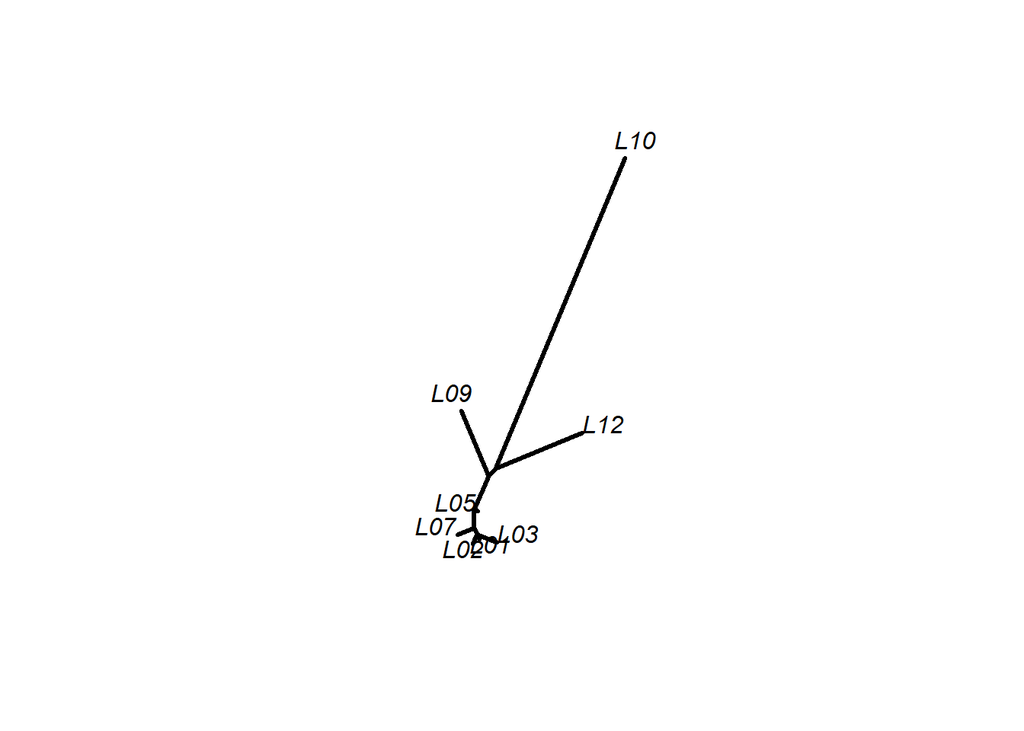

```r
#library(ape) # required package to visualize the tree using the "nj" function

Tree <- nj(as.dist(FstValues$Fsts)) # conversion of the Fst values to a tree object

plot.phylo(Tree,type="unrooted",show.tip.label=TRUE,edge.width=3,rotate.tree=90)
add.scale.bar(length = 0.05,lwd=2,x=0.25,y=0.15,col="black")
```

## 2.6 Heterozygosity

To estimate heterozygosities for each population, we can use the Hs function of the package ‘adegenet’. This function works with the genind data class. Thus, First we convert our VCF file to a genind object:

```r
# Convert the VCF file that we work with 'SeagrassSNPdata.vcf' to a genind object
genind.data <- vcfR2genind(vcf)
```

We specify our populations:

```r
pops <- as.factor(c(SampleInfo$Site))
pop(genind.data) <- pops
```

Then we apply the Hs function on these data to obtain the average heterozygosity for each population:

```r
Hs(genind.data)
```

```
##       L12       L03       L07       L01       L02       L09       L10       L05
## 0.2088724 0.2215545 0.2234990 0.2253822 0.2228514 0.2141354 0.1774225 0.2246936
```

## 2.7 Principal component analysis

We can also perform a PCA directly on our genlight data:

```r
pca.1 <- glPca(genlight.data.reduced, nf=2)

#when nf=2 (number of retained factors) is not specified, the function displays the barplot ofeigenvalues of the analysis and asks the user for a number of retained principal components.

pca.1$eig[1]/sum(pca.1$eig) # proportion of variation explained by 1st principal component
```

```
## [1] 0.05871756
```

```r
pca.1$eig[2]/sum(pca.1$eig) # proportion of variation explained by 2nd principal component
```

```
## [1] 0.03069607
```

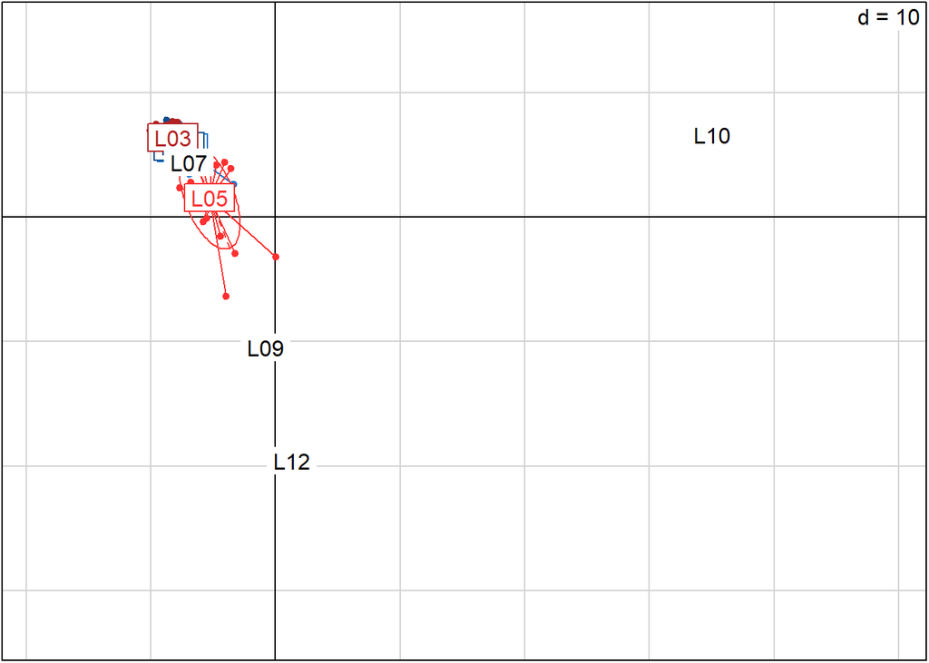

```r
# plot the samples along the first two principle components showing groups
s.class(pca.1$scores, pop(genlight.data.reduced), col=colors()[c(131,132,133,134)])
```

# 3 Discussion